# チョコレートの消費量とノーベル賞受賞者の関係

タナカケンタ

(https://mana.bi/)

2020-05-25

## ネタ元

[Chocolate and the Nobel Prize – a true story? » G-Forge](http://gforge.se/2012/12/chocolate-and-nobel-prize/)のコードを、ほぼそのまま借用しています。

## ノーベル賞受賞者データの取得

元記事のXMLパッケージ + `readHTMLTable()` 関数では動かなかったので、rvestパッケージを使ったコードに直しました。また、テーブルの列名などが少し変更されていたので対応しました。

```r
library(rvest) # 元記事のXML + readHTMLでは動かなかったので
theurl <- "https://en.wikipedia.org/wiki/List_of_countries_by_Nobel_laureates_per_capita"
tables <- read_html(theurl) %>% html_nodes("table") %>%
  .[1] %>% html_table(trim = T)

nobel_prizes <- tables[[1]]

# Clean column names
colnames(nobel_prizes) <-
  gsub(" ", "_",
       gsub("(/|\\[[0-9]+\\])", "",
            gsub("\n", " ", colnames(nobel_prizes))
        )
    )

# Delete those that aren't countries and thus lack rank
nobel_prizes$Rank <- as.numeric(as.character(nobel_prizes$Rank))
nobel_prizes <- subset(nobel_prizes, is.na(Rank) == FALSE)

# Clean the country names
nobel_prizes$Entity <-
  gsub("[^a-zA-Z ]", "", nobel_prizes$Entity)

# Clean the loriates variable
nobel_prizes$Laureates10_million <-
  as.numeric(as.character(nobel_prizes$Laureates10_million))
```

## スイスのチョコレート消費量データの入力

スクレイピング先にデータがないため、手入力する必要があるようです。ここも、列名 (Country → Entity) の変更があります。

```r
nobel_prizes$Chocolate_consumption <- NA
# http://www.chocosuisse.ch/web/chocosuisse/en/documentation/faq.html
nobel_prizes$Chocolate_consumption[nobel_prizes$Entity == "Switzerland"] <- 11.9
```

## ドイツ語による国名表記の英語への変換

スクレイピング先のサイトがドイツ語で書かれているためです。rvestを用いた記述に書き換えました。

```r
# Translation from German to English
theurl <- "https://www.thoughtco.com/countries-of-the-world-index-4101906"

tables <- read_html(theurl) %>% html_nodes("table") %>%
  .[1] %>% html_table(trim = T)

translate_german <- tables[[1]]
translate_german <- translate_german[3:nrow(translate_german), 1:2]
colnames(translate_german) <- c("English", "German")
translate_german$German <-
    gsub("([ ]+(f|pl)\\.$|\\([[:alnum:] -]+\\))", "", translate_german$German)
```

## 国別チョコレート消費量データの取得

ドイツのチョコレートメーカー? のサイトに記載されている、国別のチョコレート消費量を取得します。rvestを用いた記述に書き換えました。また、ノーベル賞受賞者数のテーブルではCountryではなく、Entity (地域?) になっているため、最後のSQL文を書き換えました。

```r
# Get the consumption from a German list
theurl <- "http://www.theobroma-cacao.de/wissen/wirtschaft/international/konsum"

tables <- read_html(theurl) %>% html_nodes("table") %>%
  .[1] %>% html_table(trim = T)

german_chocolate_data <- tables[[1]][2:nrow(tables[[1]]), ]
names(german_chocolate_data) <- c("Country", "Chocolate_consumption")
german_chocolate_data$Country <-
    gsub("([ ]+f\\.$|\\([[:alnum:] -]+\\))", "", german_chocolate_data$Country)

library(sqldf)

sql <- paste0("SELECT gc.*, tg.English as Country_en",
              " FROM german_chocolate_data AS gc",
              " LEFT JOIN translate_german AS tg",
              " ON gc.Country = tg.German",
              " OR gc.Country = tg.English")
german_chocolate_data <- sqldf(sql)

german_chocolate_data$Country <-
    ifelse(is.na(german_chocolate_data$Country_en),
    german_chocolate_data$Country,
    german_chocolate_data$Country_en)

german_chocolate_data$Country_en <- NULL
german_chocolate_data$Chocolate_consumption_tr <- NA
for (i in 1:nrow(german_chocolate_data)) {
    number <- as.character(german_chocolate_data$Chocolate_consumption[i])
    if (length(number) > 0) {
        m <- regexpr("^([0-9]+,[0-9]+)", number)
        if (m > 0) {
            german_chocolate_data$Chocolate_consumption_tr[i] <-
                as.numeric(
                    sub(",", ".", regmatches(number, m))
                )
        } else {
            m <- regexpr("\\(([0-9]+,[0-9]+)", number)

            if (m > 0)
                german_chocolate_data$Chocolate_consumption_tr[i] <-
                    as.numeric(
                        sub("\\(", "",
                            sub(",", ".", regmatches(number, m))
                        )
                    )
        }
    }
}

sql <- paste0("SELECT np.*, gp.Chocolate_consumption_tr AS choc",
              " FROM nobel_prizes AS np",
              " LEFT JOIN german_chocolate_data AS gp",
              " ON gp.Country = np.Entity")
nobel_prizes <- sqldf(sql)
```

## 相関係数を算出

```r
res_cor <- nobel_prizes %>% filter(!is.na(choc)) %>% select(Laureates10_million, choc) %>% cor()
res_cor
```

```
##                     Laureates10_million      choc
## Laureates10_million           1.0000000 0.7336186
## choc                          0.7336186 1.0000000
```

## 関係性をグラフで描画

一部、列名が現在取得できるテーブルのものと異なっていたので修正しました。

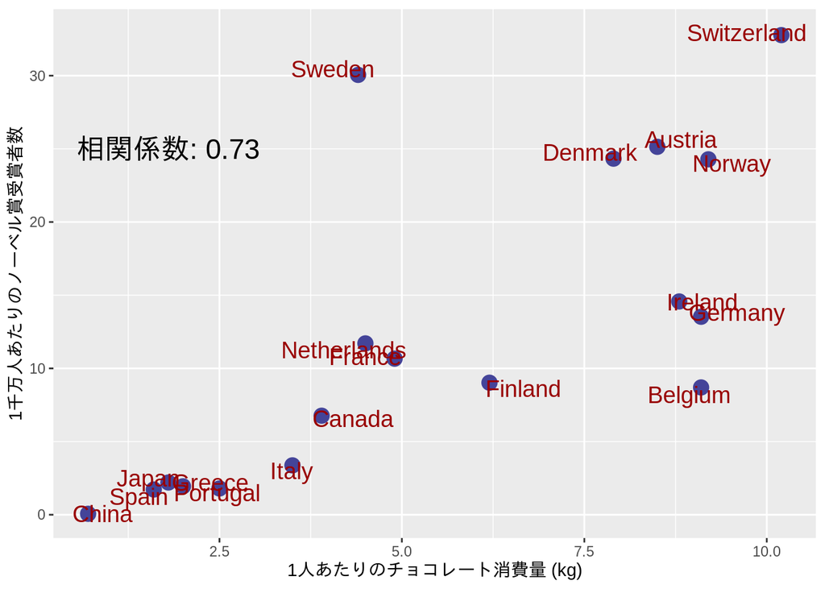

```
　　　　　 /|
ﾍ　/|/ |　　　N /i/´ ﾞ￣￣｀`ヾ)＿　　　　　　∧　　/
　V 　 .|　,　 Nヾ　ﾞ　　　　　　　　ﾞヽ　　　|＼/　∨l/
　　　　ﾚ'　7Nﾞ､　　　　　　　　　　　 ﾞi　_|｀
　　　　　 /Nﾞゞ　　　　　　　　　　　　.! ヽ　　　チ
　関　　　 7ゞミﾐ､　　ノ,彡ｲﾊヾ、　　i　Z　　　ョ
　 係　　　Zー-r-==､'リノ_ﾉ_,.ヾミ,.ｨ,ﾆi　ヽ　　 コ
　あ　　　/　　{i　｀ﾞ';l={ﾞ´石ゞ}='´ﾞ'r_/　〈　　　 と
　っ　　　|:　　 ｀iー'/　ヾ､__,.ﾉ　 /i´　　/　　　ノ
　た　　　i､ 　　　!　 ﾞﾆ-=､　 u / ,ト,　∠_　　｜
　よ　　　|｀　　　 ヽ、i'､_丿　／／/ ヽ　/_　ベ
！！　　 |　　＿,.ｨﾍヽ二 ｨ'_／　/　　ﾞi＼|／Wlﾍ　ル
　　　　　 |'￣／　i　ヽ_.／´ 　 ./　 　 .|　｀＼　賞　 ∨＼
wﾍ　 /＼|／　　/ィ´￣ﾞi　　　/　　　ir＝､　 l'i"ヽ､　は
　　∨　∠__,,..-ｲ　i　　 /＼_,ｲ,=-、　i ､,.ゞ､ | ﾞ'"ヽ ＼
! 　 　 .i-'´　　,i | ./｀ﾞ'i'　　 /i_.!._,..ヽ＜!　　ﾞi､ﾞi.　 =ﾞ!　 ＼
!　　　 |　　　.,iﾞ::|/　　.|　 ,/::/-i　　 ﾞi　ﾞi　三ﾞi ﾞi　　 | /⌒
i/　　 .|　　　,iﾞ:::i'　 　 | ,/ ::/= .|三.　ﾞi/.|　　 .| .|　　.ij:.
.l〉　　 |　　 ,iﾞ :::|　　　.!' ::::iﾞ'i　　ﾄ.　　ﾞi　|　_,.. V　＝,!
　!　　 |　　,iﾞ ::::|　　 / ::::::|　l=　ヾ!.._　ヽ｣　"´;i　　:.:i　./
. |　　 .|　 .,i ::::::|　 ,/::::::::::|　 ヾ:.:.　ヾ::"　ﾞ　　　　　/／
│　　 |　 ,i::::::::| ,/ .::::::::: |　　　ﾞi.:.:.:.:.:､:.:.:.:.:.:.:.:.:.:／,ｨ'"´
.| 　 　 |　 i::::::::,ｲ::::::::::::::::|　　　/ﾄ､;:;:;:;:;:;:;:;:;:;::,ノi|Y
```

```
　　　　　　　　　ナ ゝ　　　ナ ゝ　/　 　 十＿"　 　 ー;=‐　　　　　　　　　|! |!
　　　　　　　　　　cト　　　　cト　/＾､_ﾉ　 | ､.__　つ　 （.__ 　 ￣￣￣￣ 　 ・ ・
ミﾐ:::;,!　　　　　　u　　　　　　　｀ﾞ"~´　　　ヾ彡::l／VvVw、 ,yvヾNヽ　　ゞヾ　 ,.　,.　,.　、､ヾゝヽr＝ヾ
ﾐ::::;/　　￣ﾞ`ｰ-.､　　　　　u　　;,,;　　　j　　 ヾk'!　' l　/ 'ﾚ ^ヽﾍ＼　　 ,rﾞゞﾞ-"､ノ /　l!　!ヽ ､､　|
ミ/　　　　J　　　ﾞ`ｰ､　　　"　;, ;;;　,;;　ﾞ　　u ヾi　　　 ,,./　,　,､ヾヾ　　 | '-- ､..,,ヽ　 j　 !　| Nヾ|
'"　　　　　　　_,,.. -─ゝ.､　　　;, "　;;　　　_,,..._ゞｲ__／/〃 i.! ilヾゞヽ　 | ､　 .r．　ヾ-､;;ﾉ,.:-一'"i
　　j　　　　／　　 ,.- ､　 ヾヽ、　;; ;;　_,-＜　　/／_,,＼' "' !|　:l ﾞi !_,,ヽ.l　`ー─--　 ｴｨ' (． 7 /
　　　　　　:　　　　' ・丿　　￣≠Ξｲ´,-､　ヽ /ｲ´ r．　`ー-'ﾒ ,.-´､　　i　　　　 u　　ヾ｀`ー' ｲ
　　　　　　 ＼_　　　 _,,......::　　　´ﾞi､　`¨　/　i　ヽ.__,,... '　 u ﾞl´.i･j.冫,ｲﾞl　 ／ ｀`-､..-　ノ　:u l
　　　u　　　　　￣￣　　彡"　　　、ヾ￣｀`ﾐ::.l　　u　　　j　　i､｀ー'　.i /　/､._　　　　｀'y　　 /
　　　　　　　　　　　　　　u　　　　　　｀ヽ　　ﾞ:l　　 ,.::- ､,,　,.　ノ　ﾞ u　!　/_　　￣　ー/　u　/
　　　　　　　　　　　_,,..,,_　　　　,.ｨ､　 ／　　　|　 /__　　 ｀`- ､_　　　 l　l　 ｀`ｰt､_　/　　／
　　ﾞ　　　u　　,.／´　"　 ｀`- ､_Ｊ　r'´　 u　丿　.l,...　｀ー一''/　　　ノ　 ﾄ ､,,_____　ﾞ/　／
　　　　　　　 ./＿_　　　　　　　　ｰ７　　　　/、　l　　 'ﾞ　ヽ/　 ,. '"　　＼｀ｰ--- ",.::く､
　　　　　　　/;;;''"　￣￣ ───/　　ﾞ　 ,::'　 ＼ヾﾆ==＝'"／ ｀- ､　　　ﾞー┬ '´　/　＼..,,__
、　　　　　 .i:⌒`─-､_,....　　　　l　　　／　　　　 ｀ー┬一'　　　　　 ヽ　　　 :l　 ／　 , '　｀ソヽ
ヾヽ　　　　 l　　　　　 `　 ｀ヽ、 l　 .／　　ヽ　　　　　 l　　　　　　　　　）　　,; ／　　　,'　　　　'^i
```

```r
library(ggplot2)
ggplot(data = subset(nobel_prizes, is.na(choc) == FALSE), aes(x = choc, y = Laureates10_million)) +
    ylab("1千万人あたりのノーベル賞受賞者数") + xlab("1人あたりのチョコレート消費量 (kg)") +
    geom_point(size = 4, colour = "#444499") + geom_text(aes(label = Entity),
    size = 5, position = position_jitter(width = 0.5, height = 0.5), colour = "#990000") + annotate("text", x = 1.8, y = 25, label=paste("相関係数:", round(res_cor[1, 2], 2)), size = 6)
```

AAって難しいね (›´ω`‹ ) ｹﾞｯｿﾘ

## BMIデータを追加

ついでに、BMI (Body mass index) の国別データも取得し、追加してみたそうです。OECDのライブラリから、2012年の調査データを取得するようですが、URLが変更されていたので、修正しました。

```r
# Percentage of males with a BMI > 25 kg/m2
tables <- read_html("https://www.oecd-ilibrary.org/sites/ovob-ml-table-2012-2-en/index.html?itemId=/content/component/ovob-ml-table-2012-2-en") %>% html_nodes("table") %>% .[1] %>% html_table(trim = T)

ob <- tables[[1]]
ob[, 2] <- as.character(ob[, 2])
ob <- apply(ob, FUN = as.character, MARGIN = 2)
ob <- ob[, 2:ncol(ob)]
ob <- ob[4:nrow(ob), ]

last_obesitas <- apply(apply(ob[, 2:ncol(ob)], FUN = as.numeric, MARGIN = 2),
    MARGIN = 1, FUN = function(x) {
        if (any(is.na(x) == FALSE))
            return(x[max(which(is.na(x) == FALSE))]) else return(NA)
    })

ob <- data.frame(Country = ob[, 1], last_obesitas = last_obesitas)
ob <- subset(ob, is.na(last_obesitas) == FALSE)

sql <- paste0("SELECT np.*, ob.last_obesitas AS obesitas",
              " FROM nobel_prizes AS np",
              " LEFT JOIN ob", " ON ob.Country = np.Entity")
nobel_prizes <- sqldf(sql)
```

## チョコレートの消費量とノーベル賞受賞者数、BMIの関係をグラフで描画

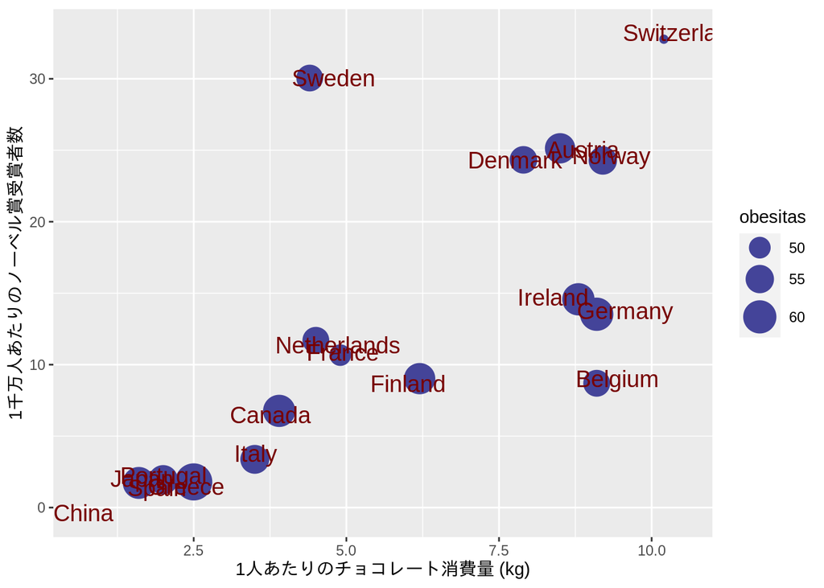

```r
ggplot(data = subset(nobel_prizes, is.na(choc) == FALSE), aes(x = choc, y = Laureates10_million)) +
    ylab("1千万人あたりのノーベル賞受賞者数") + xlab("1人あたりのチョコレート消費量 (kg)") +
    geom_point(aes(size = obesitas), colour = "#444499") + scale_size(range = c(2,
    10)) + geom_text(aes(label = Entity), size = 5, position = position_jitter(width = 0.5,
    height = 0.5), colour = "#770000")
```

## チョコレート消費量とノーベル賞受賞者数の線形回帰モデル

目的変数を受賞者数 (の割合)、説明変数をチョコレートの消費量としているので、「ノーベル賞の受賞者数は、チョコレートの消費量によって説明できる」と仮定した因果モデルですね。列名が少し異なっているので修正しました。

```r
fit <- lm(Laureates10_million ~ choc, data = nobel_prizes)
summary(fit)
```

```
##
## Call:
## lm(formula = Laureates10_million ~ choc, data = nobel_prizes)
##
## Residuals:
##     Min      1Q  Median      3Q     Max
## -12.552  -3.884  -1.087   2.534  20.362
##
## Coefficients:
##             Estimate Std. Error t value Pr(>|t|)
## (Intercept)  -1.1304     3.5830  -0.316  0.75646
## choc          2.4593     0.5695   4.318  0.00053 ***
## ---
## Signif. codes:  0 '***' 0.001 '**' 0.01 '*' 0.05 '.' 0.1 ' ' 1
##
## Residual standard error: 7.429 on 16 degrees of freedom
##   (56 observations deleted due to missingness)
## Multiple R-squared:  0.5382, Adjusted R-squared:  0.5093
## F-statistic: 18.65 on 1 and 16 DF,  p-value: 0.0005302
```